# 单变量绘图

```
##  [1] "X"                    "fixed.acidity"        "volatile.acidity"
##  [4] "citric.acid"          "residual.sugar"       "chlorides"
##  [7] "free.sulfur.dioxide"  "total.sulfur.dioxide" "density"
## [10] "pH"                   "sulphates"            "alcohol"
## [13] "quality"
```

```
##        X          fixed.acidity   volatile.acidity  citric.acid
##  Min.   :   1.0   Min.   : 4.60   Min.   :0.1200   Min.   :0.000
##  1st Qu.: 400.5   1st Qu.: 7.10   1st Qu.:0.3900   1st Qu.:0.090
##  Median : 800.0   Median : 7.90   Median :0.5200   Median :0.260
##  Mean   : 800.0   Mean   : 8.32   Mean   :0.5278   Mean   :0.271
##  3rd Qu.:1199.5   3rd Qu.: 9.20   3rd Qu.:0.6400   3rd Qu.:0.420
##  Max.   :1599.0   Max.   :15.90   Max.   :1.5800   Max.   :1.000
##  residual.sugar     chlorides       free.sulfur.dioxide
##  Min.   : 0.900   Min.   :0.01200   Min.   : 1.00
##  1st Qu.: 1.900   1st Qu.:0.07000   1st Qu.: 7.00
##  Median : 2.200   Median :0.07900   Median :14.00
##  Mean   : 2.539   Mean   :0.08747   Mean   :15.87
##  3rd Qu.: 2.600   3rd Qu.:0.09000   3rd Qu.:21.00
##  Max.   :15.500   Max.   :0.61100   Max.   :72.00
##  total.sulfur.dioxide    density             pH          sulphates
##  Min.   :  6.00       Min.   :0.9901   Min.   :2.740   Min.   :0.3300
##  1st Qu.: 22.00       1st Qu.:0.9956   1st Qu.:3.210   1st Qu.:0.5500
##  Median : 38.00       Median :0.9968   Median :3.310   Median :0.6200
##  Mean   : 46.47       Mean   :0.9967   Mean   :3.311   Mean   :0.6581
##  3rd Qu.: 62.00       3rd Qu.:0.9978   3rd Qu.:3.400   3rd Qu.:0.7300
##  Max.   :289.00       Max.   :1.0037   Max.   :4.010   Max.   :2.0000
##     alcohol         quality
##  Min.   : 8.40   Min.   :3.000
##  1st Qu.: 9.50   1st Qu.:5.000
##  Median :10.20   Median :6.000
##  Mean   :10.42   Mean   :5.636
##  3rd Qu.:11.10   3rd Qu.:6.000
##  Max.   :14.90   Max.   :8.000
```

#### 该数据集包含了1599条红酒记录，共12个变量（其中11个基于物理测试的输入变量，1个基于主观感受的输出变量）

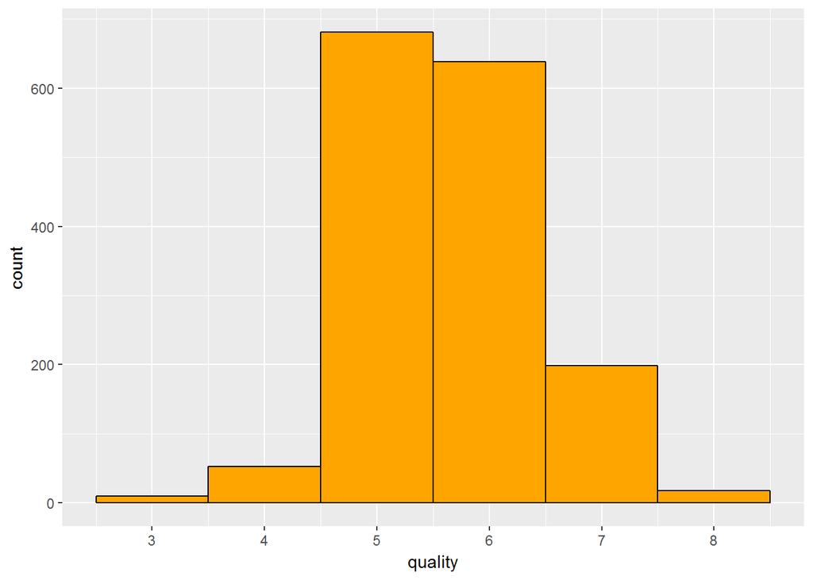

```
##    Min. 1st Qu.  Median    Mean 3rd Qu.    Max.
##   3.000   5.000   6.000   5.636   6.000   8.000
```

#### 评分最低分为3分，最高分为8分（满分10分），平均分为5.636，中位数6分；大部分都分布在5-6分之间，符合正态分布。

##### *fixed.acidity*

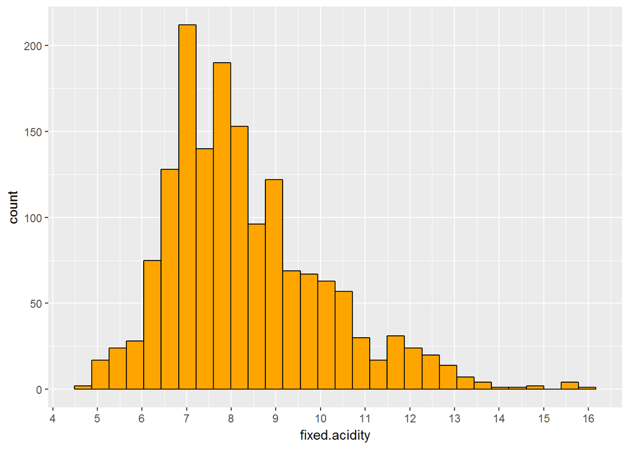

```r
plot_h('fixed.acidity',30) +
  scale_x_continuous(breaks = seq(4,16,1))
```

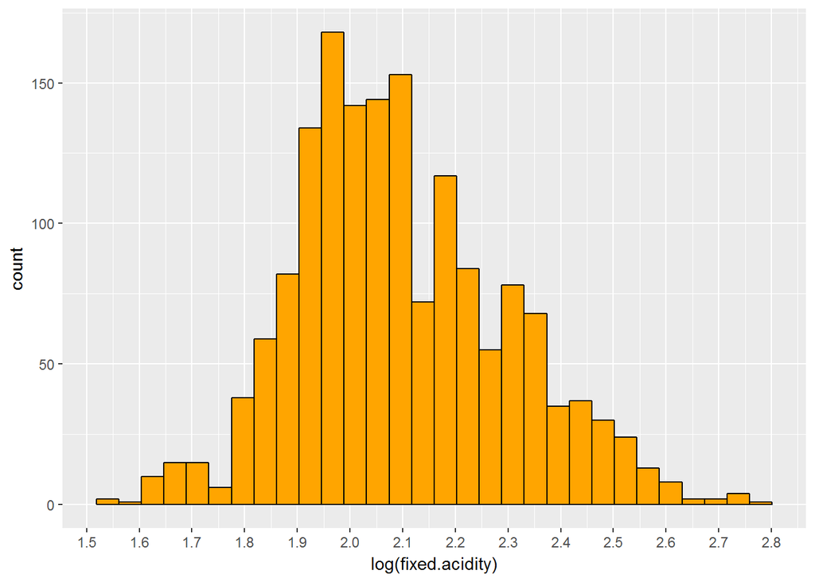

```r
plot_h('log(fixed.acidity)',30) +
  scale_x_continuous(breaks = seq(1.5,3,0.1))
```

```r
summary(wine$fixed.acidity)
```

```
##    Min. 1st Qu.  Median    Mean 3rd Qu.    Max.
##    4.60    7.10    7.90    8.32    9.20   15.90
```

##### *volatile.acidity*

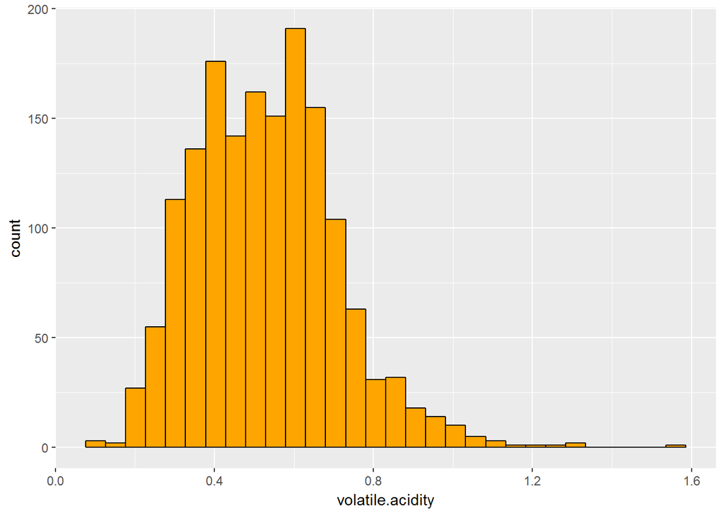

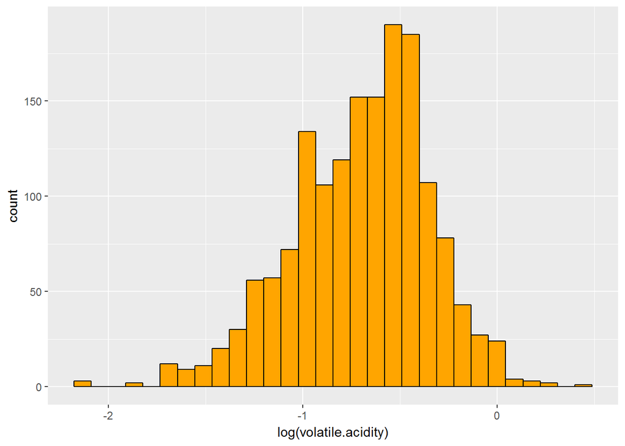

```
##    Min. 1st Qu.  Median    Mean 3rd Qu.    Max.
##  0.1200  0.3900  0.5200  0.5278  0.6400  1.5800
```

##### *citric.acid*

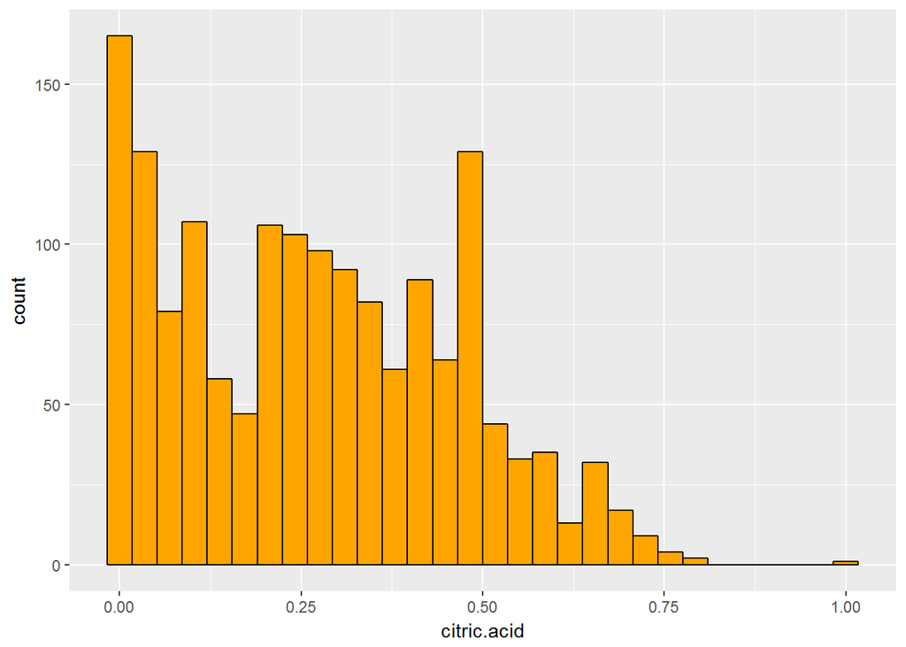

```
##    Min. 1st Qu.  Median    Mean 3rd Qu.    Max.
##   0.000   0.090   0.260   0.271   0.420   1.000
```

#### fixed acidity 最低为4.6，最高为15.90，平均为8.32，中位数是7.9；大部分分布在6-10之间。原始数据略有长尾，所以进行了log变化，使分布更趋近正态分布；

#### volatile acidity 最低为0.12，最高为1.58，平均为0.5278，中位数是0.52；大部分分布在0.3-0.7之间。原始数据长尾，所以进行了log变化；

#### citric acidity 最低为0，最高为1，平均为0.271，中位数是0.26；出现了两个峰值，一个是在0的时候，猜测为很多红酒并没有添加柠檬酸；另一个是出现在0.49。超过0.75的几乎没有了，但在1的时候存在一个观察值。

##### *residual.sugar*

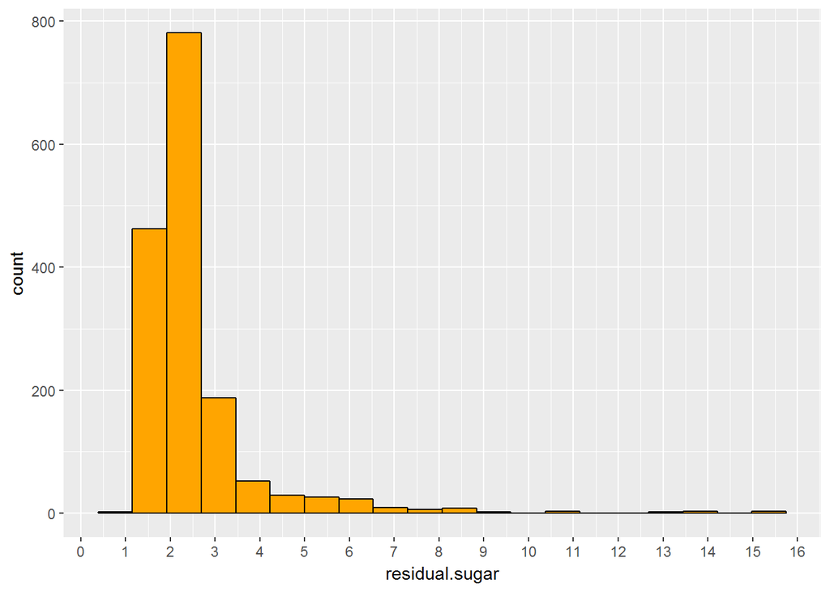

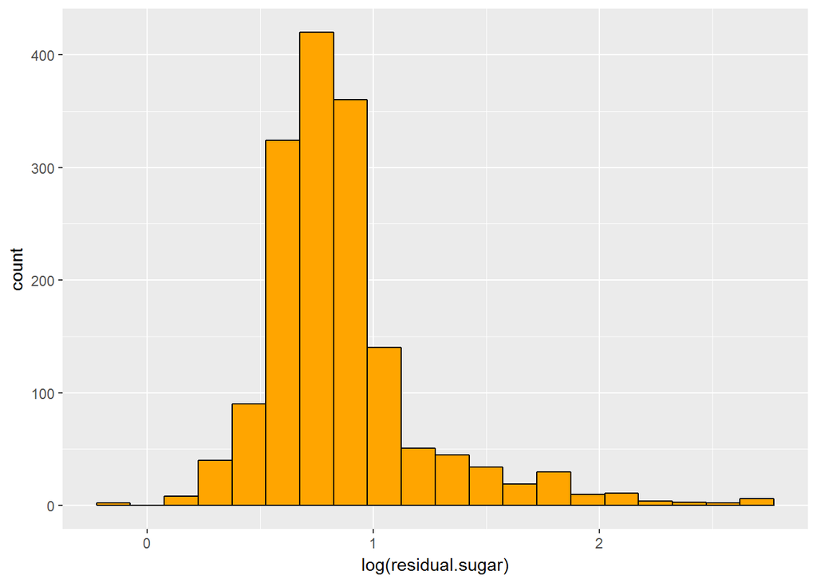

```
##    Min. 1st Qu.  Median    Mean 3rd Qu.    Max.
##   0.900   1.900   2.200   2.539   2.600  15.500
```

#### residual sugar 最低为0.9，最高为15.5，平均为2.539，中位数是2.2；大部分都分布在1.5-2.6之间，最高峰出现在2的时候，大于7的就已经很少了，数据存在长尾，进行了log变化。

##### *chlorides*

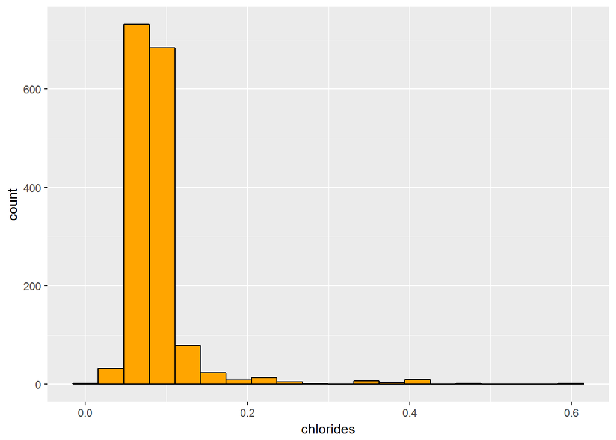

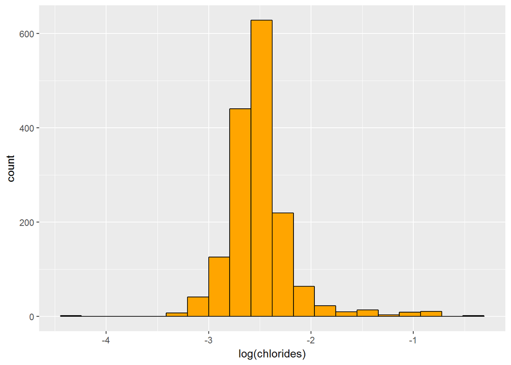

```
##    Min. 1st Qu.  Median    Mean 3rd Qu.    Max.
## 0.01200 0.07000 0.07900 0.08747 0.09000 0.61100
```

#### chlorides 最低为0.012，最高为0.611，平均为0.087，中位数是0.079；大部分都分布在0.05-0.1之间，最高峰出现在0.08的时候，大于0.2的非常少，数据存在长尾，进行了log变化。

##### *free.sulfur.dioxide*

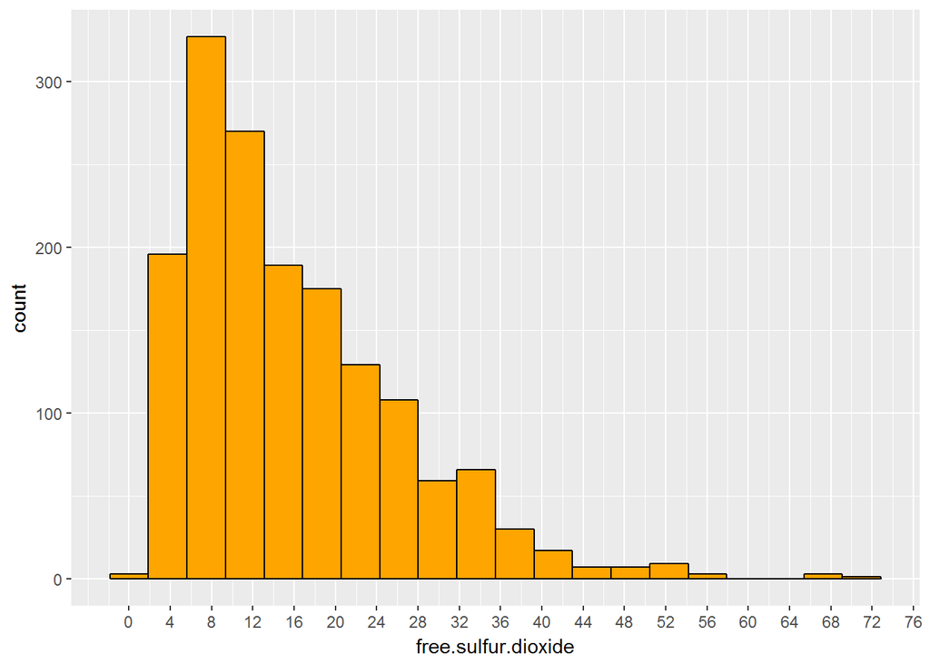

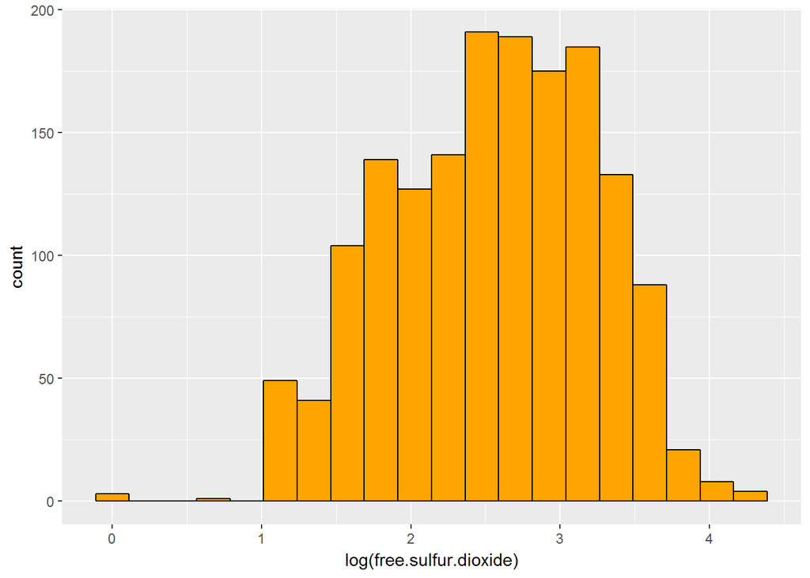

```
##    Min. 1st Qu.  Median    Mean 3rd Qu.    Max.
##    1.00    7.00   14.00   15.87   21.00   72.00
```

##### *total.sulfur.dioxide*

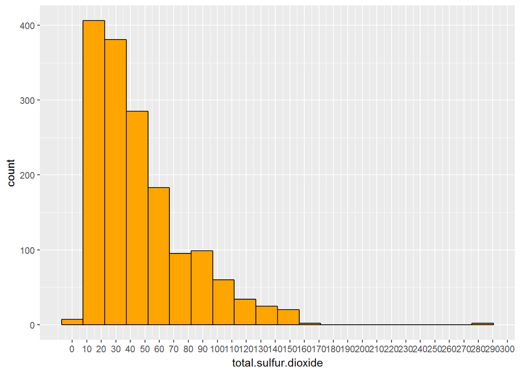

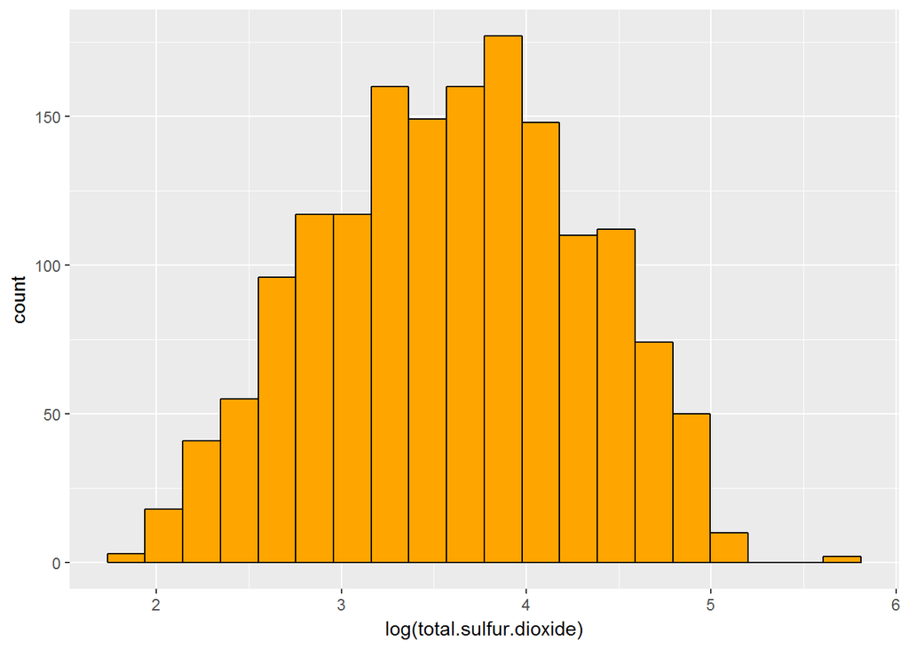

```
##    Min. 1st Qu.  Median    Mean 3rd Qu.    Max.
##    6.00   22.00   38.00   46.47   62.00  289.00
```

##### *density*

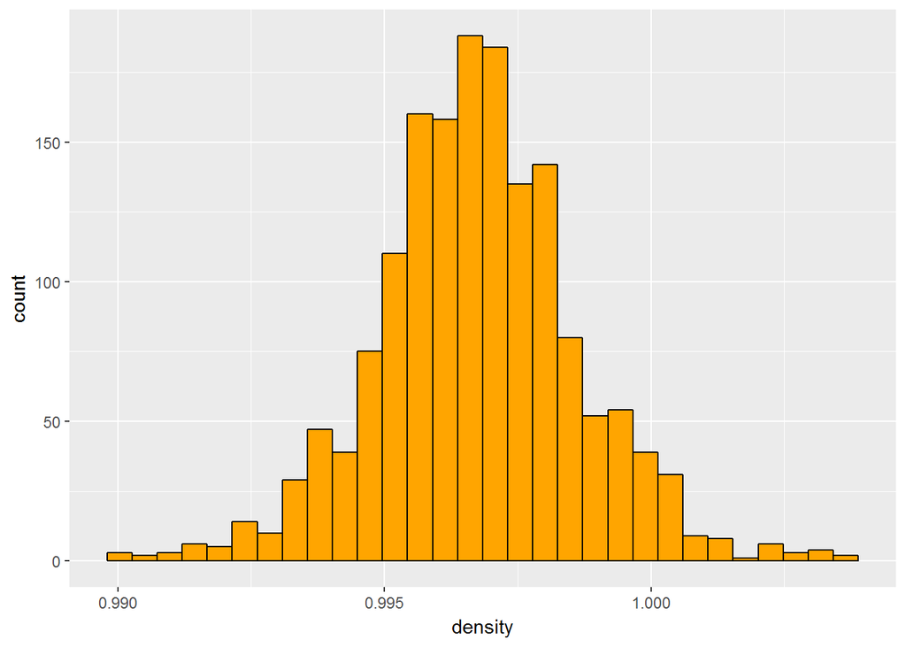

```
##    Min. 1st Qu.  Median    Mean 3rd Qu.    Max.
##  0.9901  0.9956  0.9968  0.9967  0.9978  1.0037
```

##### *pH*

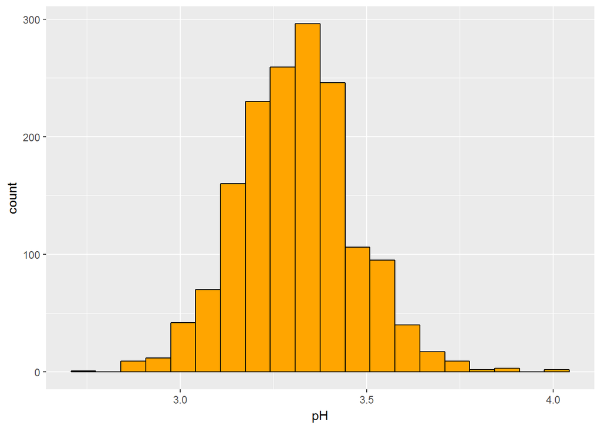

```
##    Min. 1st Qu.  Median    Mean 3rd Qu.    Max.
##   2.740   3.210   3.310   3.311   3.400   4.010
```

#### 密度最低为0.9901，最高为1.0037，平均为0.9967，中位数是0.9968；大部分都分布在0.995-1之间，符合正态分布。基本上密度都与水相似。

#### pH值最低为2.74，最高为4.01，平均为3.311，中位数是3.31；符合正态分布。

##### *sulphates*

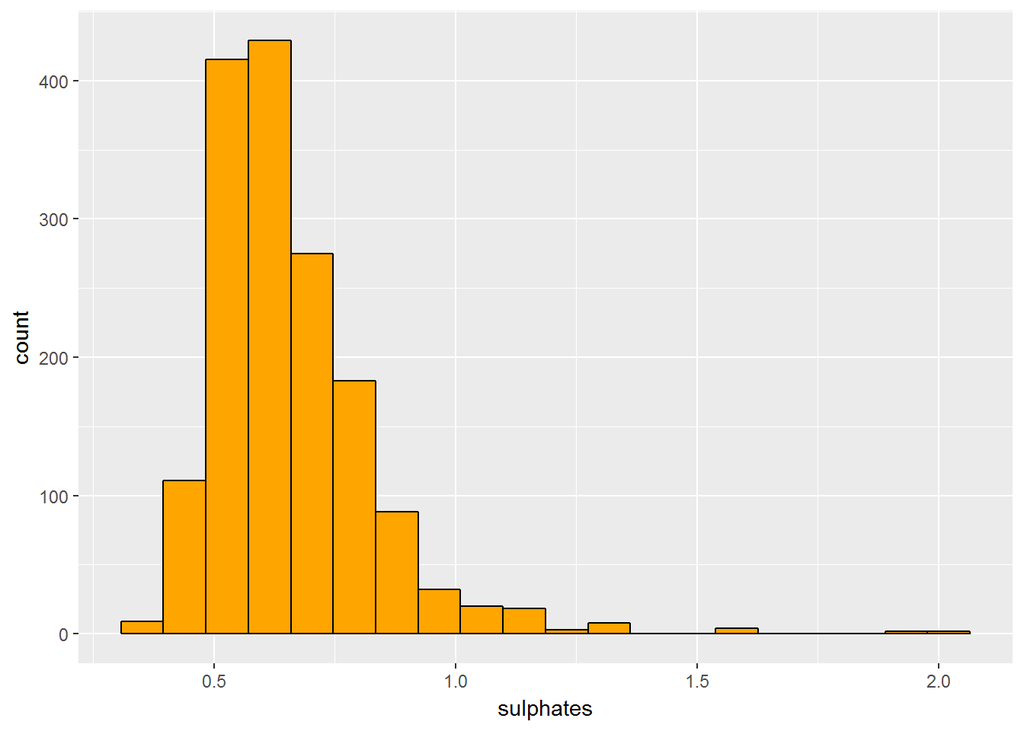

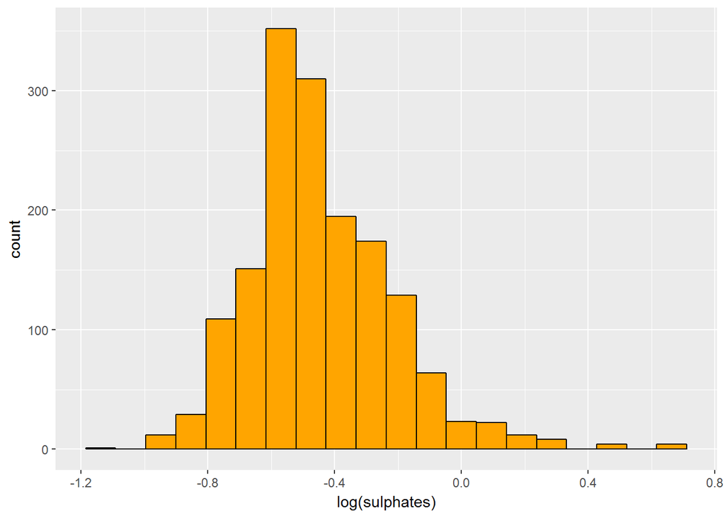

```
##    Min. 1st Qu.  Median    Mean 3rd Qu.    Max.
##  0.3300  0.5500  0.6200  0.6581  0.7300  2.0000
```

#### sulphates 最低为0.33，最高为2，平均为0.658，中位数是0.62；数据存在长尾，进行了log变化。

##### *alcohol*

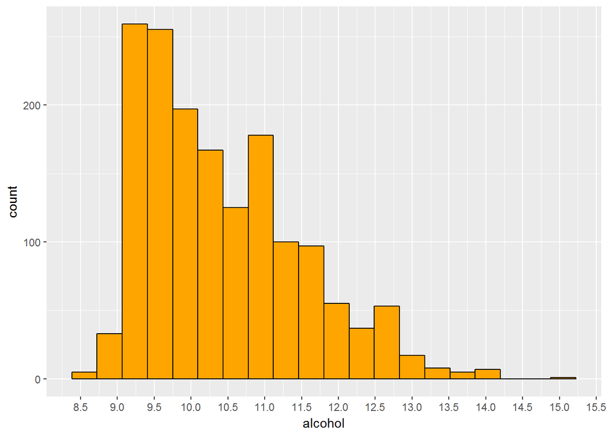

```
##    Min. 1st Qu.  Median    Mean 3rd Qu.    Max.
##    8.40    9.50   10.20   10.42   11.10   14.90
```

#### alcohol 最低为8.4，最高为14.9，平均为10.42，中位数是10.2；最高峰出现在9.5左右，随后开始逐渐下降

# 单因素分析

### **你的数据集结构是怎样的？**

#### 残糖量很少会大于7

#### 基本都会添加少量二氧化硫

#### 酒精含量基本在9-11度之间

### **主要对数据集中那些特征感兴趣？**

#### 主要对评分和几个类型的酸以及残糖比较感兴趣，因为评分是衡量酒好坏的最直观指标。而我想找出可以预测评分的最主要的几个指标，我认为几种酸和残糖跟其他元素组合可能是对于预测评分起到最关键的作用。

### **数据中其他哪些特征你认为会为你探索感兴趣的特征带来帮助?**

#### 游离二氧化硫和二氧化硫总量以及硫酸盐，他们的含量高低同样会影响酒的风味。

### **你从现有的数据集变量中创建了新的变量了么?**

#### 我暂时没有创建新的变量。

# 双变量绘图

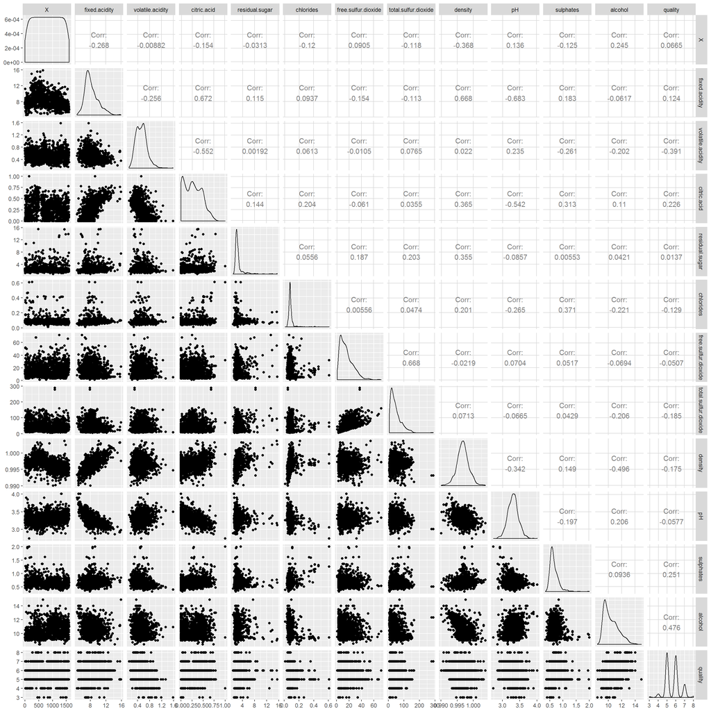

#### 可以发现评分跟挥发性酸、柠檬酸以及硫酸盐和醇适度相关，而跟其他变量似乎没有太大关系。让我们继续看下各变量详细的箱型图

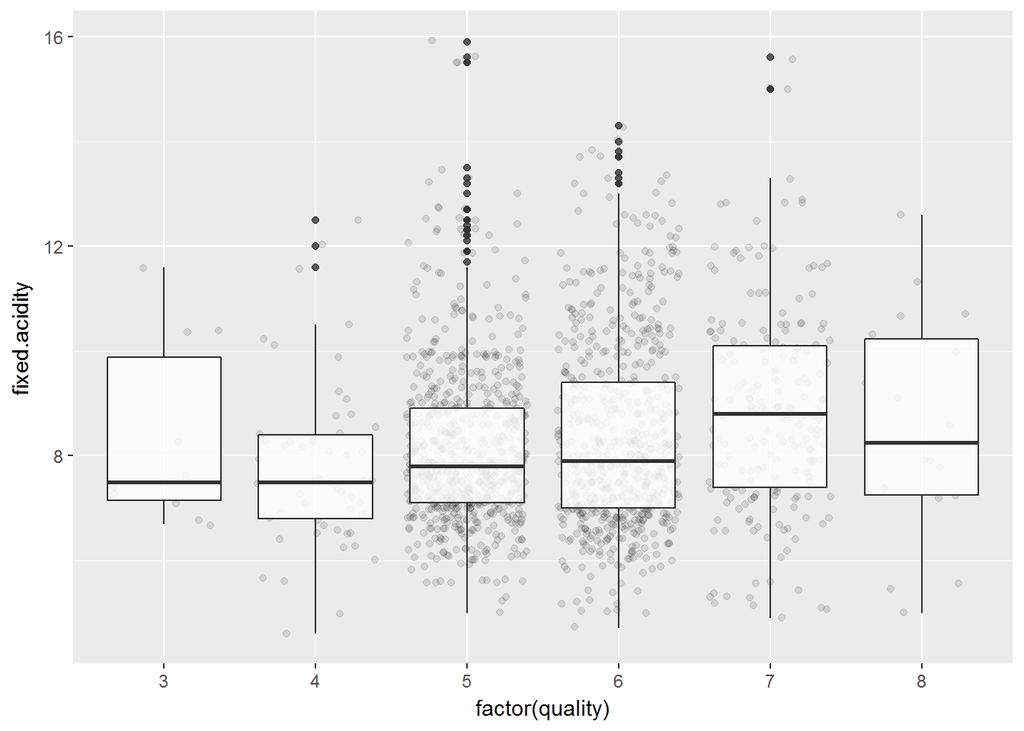

#### 固定性酸似乎确实和评分没有什么太大关系，样本多集中在评分5分到6分的区间，且固定性酸数值集中在6-10的区间。

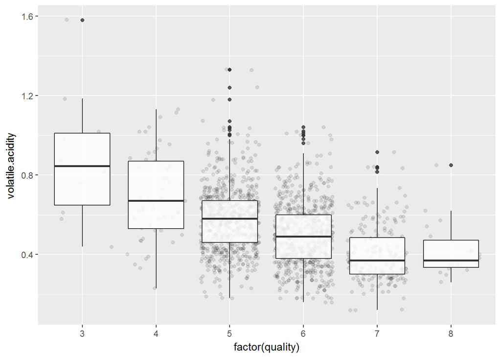

#### 可以看出随着评分的提高，挥发性酸中位数逐渐降低，样本多集中在5、6分。

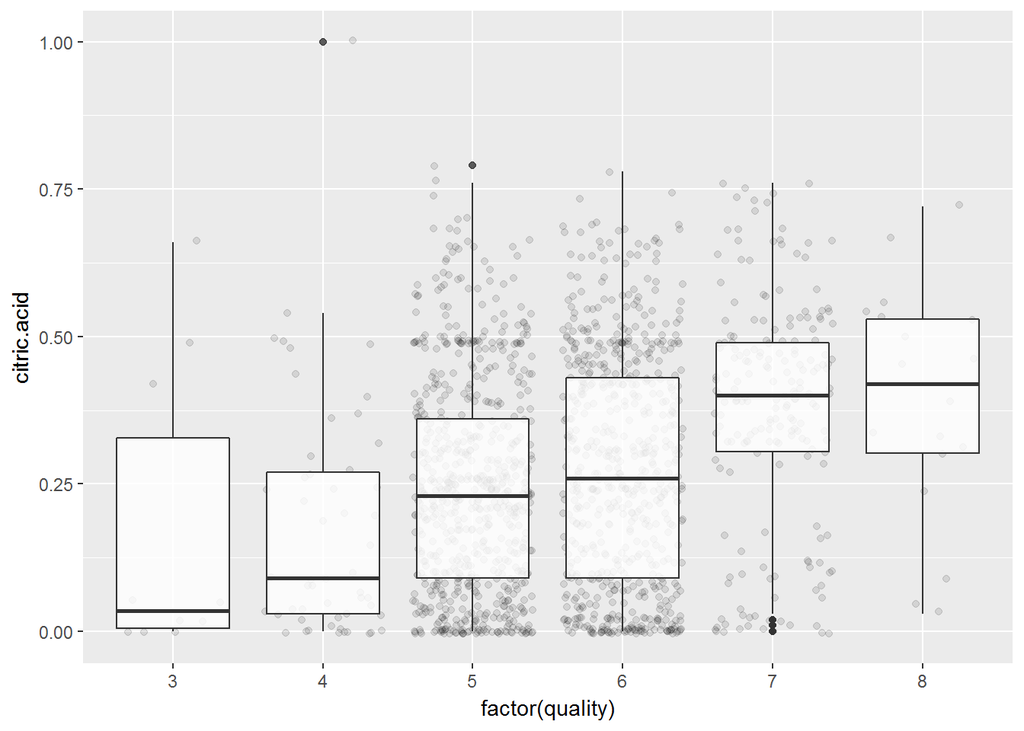

#### 可以看出随着评分的提高，柠檬酸中位数逐渐上升。然而有一个异常值，柠檬酸为1时，其评分并不高。

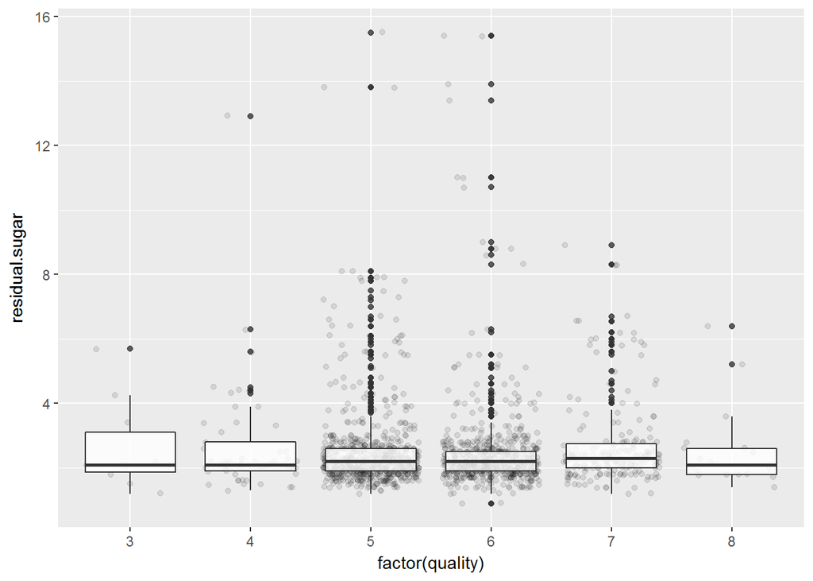

#### 残糖与评分几乎没关系

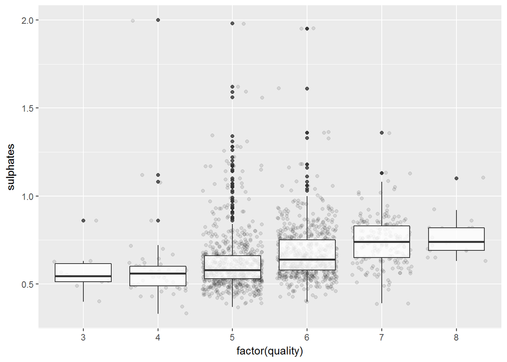

#### 随着评分的提高，硫酸盐中位数略有小幅上升。

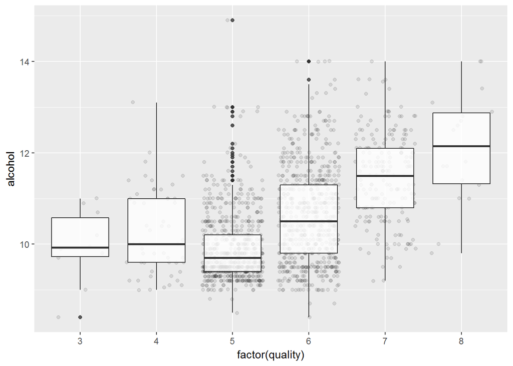

#### 随着评分的提高，酒精含量逐渐提高。但在4-5时并没有这种现象，推测酒精度数只能影响高评分的酒，对于低分的酒不管酒精度数如何都没救了。

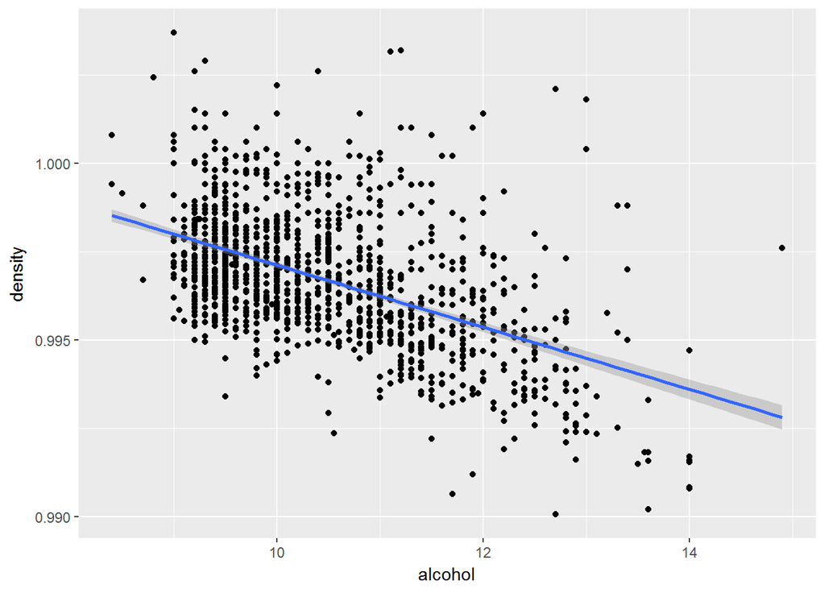

#### 酒精含量增加，密度降低，符合我们的物理认知。

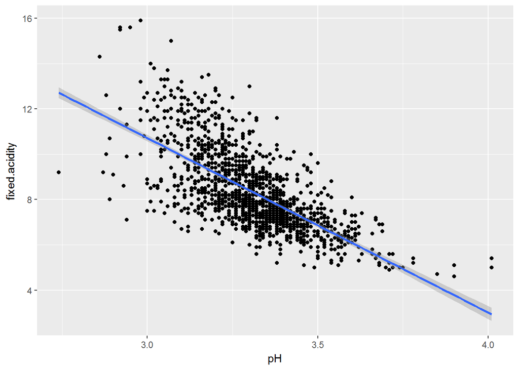

#### 这是目前发现的相关性最强的一组变量。pH和固定酸度，呈负相关。

# 双变量分析

### **Talk about some of the relationships you observed in this part of the investigation. How did the feature(s) of interest vary with other features in the dataset?**

#### 固定性酸跟评分之间关系不大，这与我开始的设想有些不同。挥发性酸跟评分有一定的相关性，呈负相关，随着挥发性酸的增加评分降低。柠檬酸跟评分呈正相关，随着柠檬酸的增加评分升高，但是柠檬酸存在一个极大值为1，该值下的评分并不高。残糖同样与评分没有太大关系，这也出乎了我的意料。硫酸盐和评分呈正相关，但在大于1.25后相关度就不高了。酒精跟评分也是呈现正相关，且相关度在所有其他变量跟评分中最高。

### **Did you observe any interesting relationships between the other features (not the main feature(s) of interest)?**

#### 酒精和密度的相关性很高，呈负相关。不过这符合我们的物理认知，我认为这是正常的。

# 多变量绘图

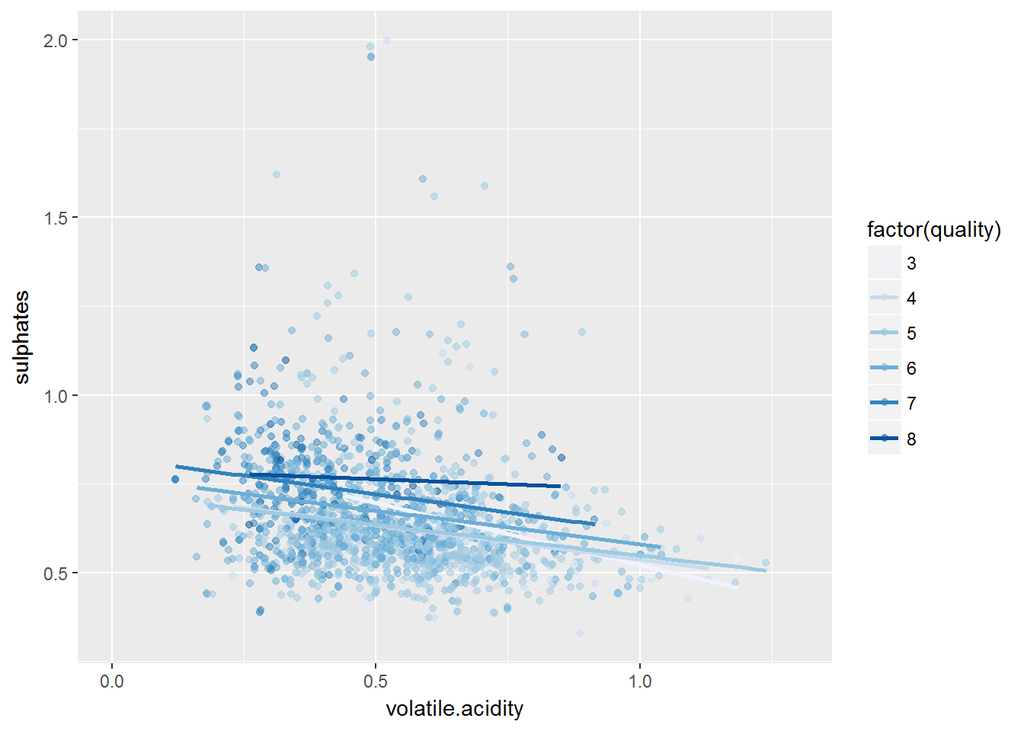

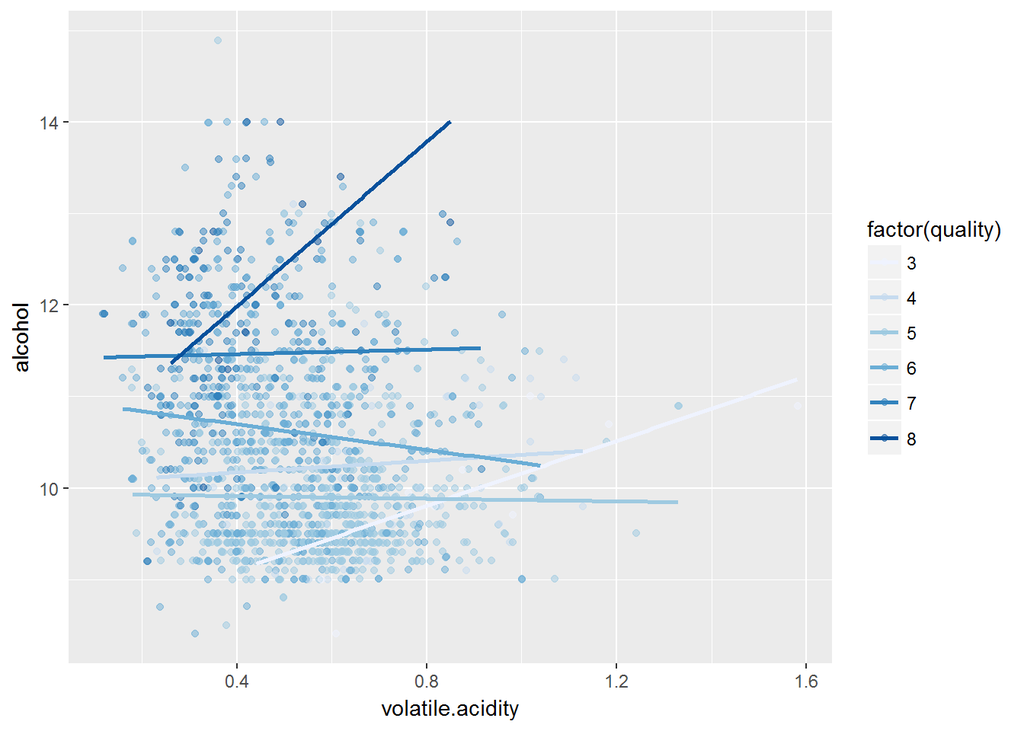

#### 酒精度数上升，评分提高；挥发性酸对于中间段的分数没有什么影响，但是对于低分和高分两个极端分数会有较大影响，对于高分段的而言，在一定范围内随着挥发性酸的升高评分提高，对于低分段的随着挥发性酸升高，评分下降。

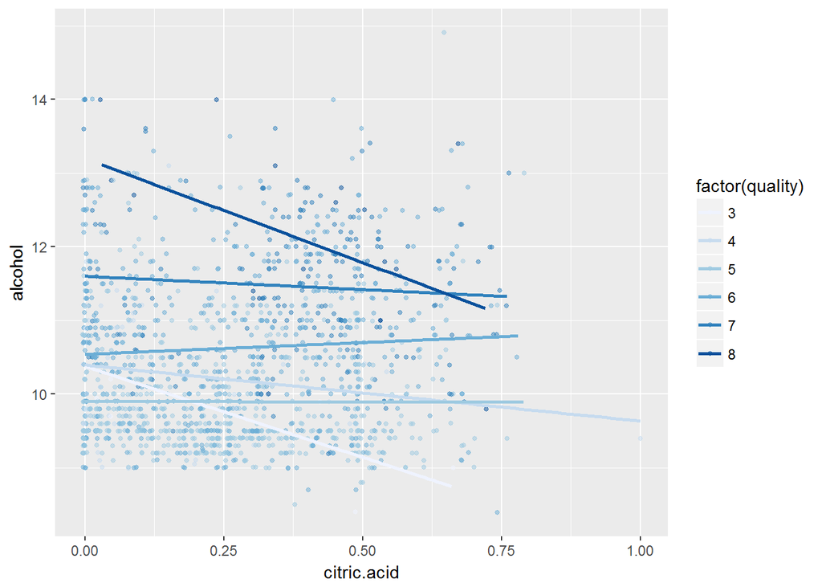

#### 对于中间分数段同样影响不大，对于高分和低分段影响较大。高分若要保持分数需随柠檬酸增加降低酒精度，而低分段若要提高分数，需提升柠檬酸和酒精含量。

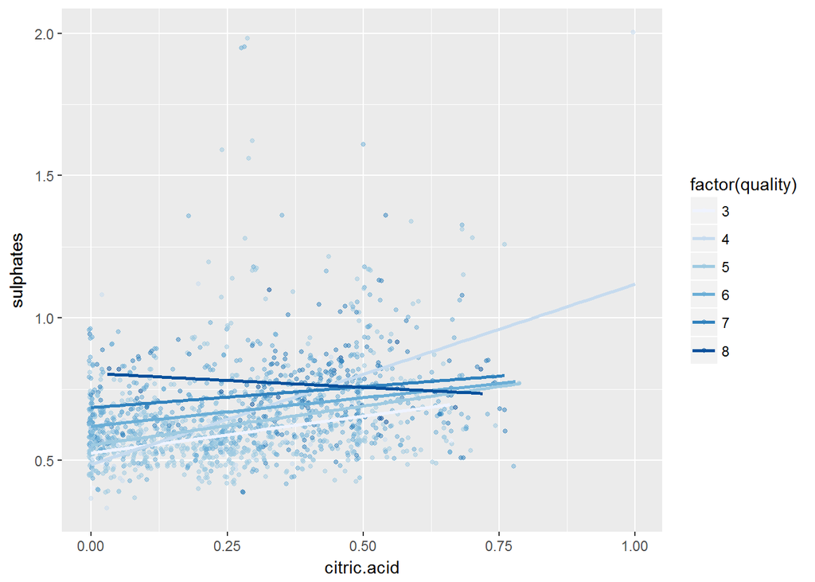